# Project: Investigate a Dataset (TMDB movies dataset)

- Introduction
- Data Wrangling
- Exploratory Data Analysis
- Conclusions

## Introduction

We will investigate the TMDB movie dataset. This dataset contains information about 10,000 movies in the period from 1960 to 2015 collected from The Movie Database (TMDb),including user ratings,revenue,budget,genres,runtime,popularity. We will ivestigate this dataset to answer some questions:

```
   1 --> What is the average budget and revenue of movies at this period?
   2 --> What is the highest rating movie and who is its director?
   3 --> Does budget affect revenue over time??
   4 --> Do genres affect revenue?
   5 --> Does runtime affect revenue over time?
   6 --> Does vote affect revenue?
```

```python
# import statements for all of the packages that we plan to use.
import pandas as pd
import numpy as nd
import matplotlib.pyplot as plt
import seaborn as scs
%matplotlib inline
```

## Data Wrangling

### General Properties

```python
# we Load our data and print some lines
df = pd.read_csv('movies.csv')
df.head()
```

|  | id | imdb_id | popularity | budget | revenue | original_title | cast | homepage | director | tagline | ... | overview | runtime | genres | production_companies | release_date | vote_count | vote_average | release_year | budget_adj | revenue_adj |
| --- | --- | --- | --- | --- | --- | --- | --- | --- | --- | --- | --- | --- | --- | --- | --- | --- | --- | --- | --- | --- | --- |
| 0 | 135397 | tt0369610 | 32.985763 | 150000000 | 1513528810 | Jurassic World | Chris Pratt\|Bryce Dallas Howard\|Irrfan Khan\|Vi... | http://www.jurassicworld.com/ | Colin Trevorrow | The park is open. | ... | Twenty-two years after the events of Jurassic ... | 124 | Action\|Adventure\|Science Fiction\|Thriller | Universal Studios\|Amblin Entertainment\|Legenda... | 6/9/15 | 5562 | 6.5 | 2015 | 1.379999e+08 | 1.392446e+09 |
| 1 | 76341 | tt1392190 | 28.419936 | 150000000 | 378436354 | Mad Max: Fury Road | Tom Hardy\|Charlize Theron\|Hugh Keays-Byrne\|Nic... | http://www.madmaxmovie.com/ | George Miller | What a Lovely Day. | ... | An apocalyptic story set in the furthest reach... | 120 | Action\|Adventure\|Science Fiction\|Thriller | Village Roadshow Pictures\|Kennedy Miller Produ... | 5/13/15 | 6185 | 7.1 | 2015 | 1.379999e+08 | 3.481613e+08 |
| 2 | 262500 | tt2908446 | 13.112507 | 110000000 | 295238201 | Insurgent | Shailene Woodley\|Theo James\|Kate Winslet\|Ansel... | http://www.thedivergentseries.movie/#insurgent | Robert Schwentke | One Choice Can Destroy You | ... | Beatrice Prior must confront her inner demons ... | 119 | Adventure\|Science Fiction\|Thriller | Summit Entertainment\|Mandeville Films\|Red Wago... | 3/18/15 | 2480 | 6.3 | 2015 | 1.012000e+08 | 2.716190e+08 |
| 3 | 140607 | tt2488496 | 11.173104 | 200000000 | 2068178225 | Star Wars: The Force Awakens | Harrison Ford\|Mark Hamill\|Carrie Fisher\|Adam D... | http://www.starwars.com/films/star-wars-episod... | J.J. Abrams | Every generation has a story. | ... | Thirty years after defeating the Galactic Empi... | 136 | Action\|Adventure\|Science Fiction\|Fantasy | Lucasfilm\|Truenorth Productions\|Bad Robot | 12/15/15 | 5292 | 7.5 | 2015 | 1.839999e+08 | 1.902723e+09 |
| 4 | 168259 | tt2820852 | 9.335014 | 190000000 | 1506249360 | Furious 7 | Vin Diesel\|Paul Walker\|Jason Statham\|Michelle ... | http://www.furious7.com/ | James Wan | Vengeance Hits Home | ... | Deckard Shaw seeks revenge against Dominic Tor... | 137 | Action\|Crime\|Thriller | Universal Pictures\|Original Film\|Media Rights ... | 4/1/15 | 2947 | 7.3 | 2015 | 1.747999e+08 | 1.385749e+09 |

5 rows × 21 columns

```python
df.info()
```

```
<class 'pandas.core.frame.DataFrame'>
RangeIndex: 10866 entries, 0 to 10865
Data columns (total 21 columns):
 #   Column                Non-Null Count  Dtype
---  ------                --------------  -----
 0   id                    10866 non-null  int64
 1   imdb_id               10856 non-null  object
 2   popularity            10866 non-null  float64
 3   budget                10866 non-null  int64
 4   revenue               10866 non-null  int64
 5   original_title        10866 non-null  object
 6   cast                  10790 non-null  object
 7   homepage              2936 non-null   object
 8   director              10822 non-null  object
 9   tagline               8042 non-null   object
 10  keywords              9373 non-null   object
 11  overview              10862 non-null  object
 12  runtime               10866 non-null  int64
 13  genres                10843 non-null  object
 14  production_companies  9836 non-null   object
 15  release_date          10866 non-null  object
 16  vote_count            10866 non-null  int64
 17  vote_average          10866 non-null  float64
 18  release_year          10866 non-null  int64
 19  budget_adj            10866 non-null  float64
 20  revenue_adj           10866 non-null  float64
dtypes: float64(4), int64(6), object(11)
memory usage: 1.7+ MB
```

# ----------------------------------------------------------------------------------------------------------------

## Assessing data

in this process we specify all Errors in our data to fix them in cleaning process.

```python
# Frist we will trim all colomns that useless in our investigation and don't help in answering our question.
usless_columns = ['id', 'imdb_id', 'cast', 'homepage', 'tagline', 'keywords', 'overview',
                  'production_companies', 'release_date', 'budget_adj', 'revenue_adj']
df.drop(usless_columns, axis=1, inplace=True)
df.info()
```

```
<class 'pandas.core.frame.DataFrame'>
RangeIndex: 10866 entries, 0 to 10865
Data columns (total 10 columns):
 #   Column          Non-Null Count  Dtype
---  ------          --------------  -----
 0   popularity      10866 non-null  float64
 1   budget          10866 non-null  int64
 2   revenue         10866 non-null  int64
 3   original_title  10866 non-null  object
 4   director        10822 non-null  object
 5   runtime         10866 non-null  int64
 6   genres          10843 non-null  object
 7   vote_count      10866 non-null  int64
 8   vote_average    10866 non-null  float64
 9   release_year    10866 non-null  int64
dtypes: float64(2), int64(5), object(3)
memory usage: 849.0+ KB
```

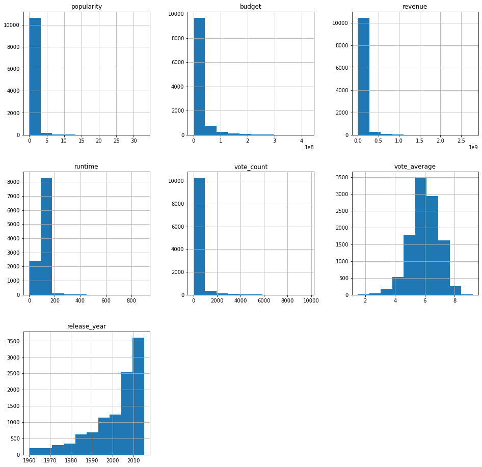

```python
# here we will visualize all numeric columns to check them
df.hist(figsize=(16, 16));
```

```python
# check for NaN values
df.isnull().any()
```

```
popularity        False
budget            False
revenue           False
original_title    False
director           True
runtime           False
genres             True
vote_count        False
vote_average      False
release_year      False
dtype: bool
```

```python
#check for dupliates
df.duplicated().sum()
```

```
1
```

```python
# check for values that doesn't make a sense in budget columns
df.budget[df.budget < 100].unique()
```

```
array([ 0, 10, 18,  1,  5, 75,  3, 80, 25,  8, 93, 97, 20, 68, 28, 32, 17,
       15, 89, 14, 90, 12, 27,  6,  2, 95, 30, 21, 11], dtype=int64)
```

```python
# check for values that doesn't make a sense in revenue columns
df.revenue[df.revenue < 100].unique()
```

```
array([ 0,  3, 80, 10, 43, 13,  9, 15, 30, 23,  2,  5, 11, 97, 12, 46, 32,
       16,  6, 78, 29, 20, 42, 27], dtype=int64)
```

```python
# check for values that doesn't make a sense in runtime columns
df.runtime[df.runtime < 60].unique()
```

```
array([ 0,  8, 31, 48,  7,  5, 56, 44,  4, 43, 14, 57, 25, 54, 52, 16, 58,
       18, 30, 17, 22,  6, 41, 23,  3,  9, 38, 36, 27, 11, 26, 59, 20, 21,
       15, 12, 47, 45, 33, 32, 42, 10, 55, 13, 40, 50, 49, 24,  2, 19, 34,
       28, 29, 53, 51], dtype=int64)
```

```python
# check for values that doesn't make a sense in runtime columns
df.runtime[df.runtime > 300].unique()
```

```
array([500, 338, 421, 540, 705, 400, 470, 501, 336, 900, 877, 366, 389,
       360, 352, 566, 561, 550, 417, 372], dtype=int64)
```

### Issues in our Data

#### 1st issue

There are NaN values (23 in genres) and (44 in derictor)

#### 2nd issue

There is one row is duplicated

#### 3th issue

There are values in the columns (budget, revenue, runtime) that don't make sense.

# ----------------------------------------------------------------------------------------------------------------

## Cleaning Data

### 1st issue

The number of NaN values in genres and derictor columns is small so we will drop it

```python
df.dropna(inplace=True)
```

### 2nd issue

We will drop duplicated rows

```python
df.drop_duplicates(inplace=True)
```

### 3st issue

There are values in the columns (budget, revenue, runtime) that don't make sense,so that we will take the minimum value that make sense and replace all values that is less than it with NaN.

```python
# we will consider the minimum value that make sense in both budget and revenue is 1,000,000$.
#  we will consider the minimum value that make sense in runtime is 1h and the maximum value is 5h.
columns = ['budget', 'revenue', 'runtime']
def fix_columns(df,coulumns):
    for column in columns:
        if column == 'budget' or column == 'revenue':
            df[column].mask(df[column] < 1000000,inplace=True)
        else:
            df[column].mask(df[column] < 60,inplace=True)
            df[column].mask(df[column] > 300,inplace=True)

fix_columns(df,columns)
```

```python
df.info()
```

```
<class 'pandas.core.frame.DataFrame'>
Int64Index: 10800 entries, 0 to 10865
Data columns (total 10 columns):
 #   Column          Non-Null Count  Dtype
---  ------          --------------  -----
 0   popularity      10800 non-null  float64
 1   budget          4802 non-null   float64
 2   revenue         4326 non-null   float64
 3   original_title  10800 non-null  object
 4   director        10800 non-null  object
 5   runtime         10483 non-null  float64
 6   genres          10800 non-null  object
 7   vote_count      10800 non-null  int64
 8   vote_average    10800 non-null  float64
 9   release_year    10800 non-null  int64
dtypes: float64(5), int64(2), object(3)
memory usage: 928.1+ KB
```

# ----------------------------------------------------------------------------------------------------------------

## Exploratory Data Analysis

### General Exploration

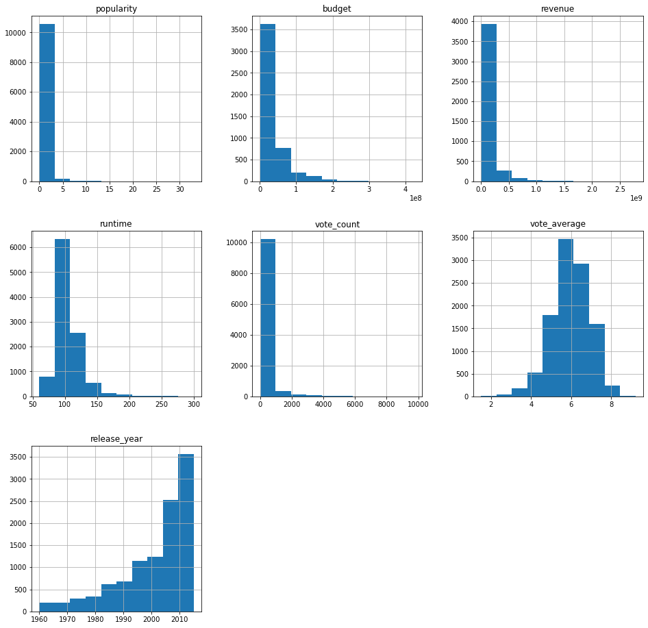

```python
df.hist(figsize=(16, 16));
```

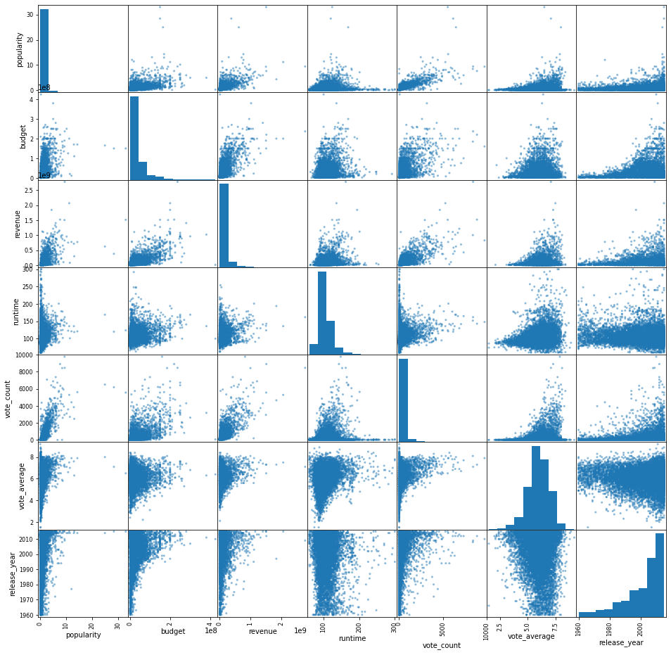

```python
# We check the relations among variables
pd.plotting.scatter_matrix(df,figsize=(16, 16));
```

```python
df.describe()
```

|  | popularity | budget | revenue | runtime | vote_count | vote_average | release_year |
| --- | --- | --- | --- | --- | --- | --- | --- |
| count | 10800.000000 | 4.802000e+03 | 4.326000e+03 | 10483.000000 | 10800.000000 | 10800.000000 | 10800.000000 |
| mean | 0.649455 | 3.306122e+07 | 9.999255e+07 | 103.788038 | 218.600741 | 5.970880 | 2001.289537 |
| std | 1.002441 | 3.941199e+07 | 1.684465e+08 | 20.934974 | 577.165055 | 0.933006 | 12.819545 |
| min | 0.000188 | 1.000000e+06 | 1.000000e+06 | 60.000000 | 10.000000 | 1.500000 | 1960.000000 |
| 25% | 0.209156 | 8.000000e+06 | 1.367963e+07 | 90.000000 | 17.000000 | 5.400000 | 1995.000000 |
| 50% | 0.385471 | 2.000000e+07 | 4.010277e+07 | 99.000000 | 39.000000 | 6.000000 | 2006.000000 |
| 75% | 0.717508 | 4.000000e+07 | 1.132711e+08 | 112.000000 | 147.000000 | 6.600000 | 2011.000000 |
| max | 32.985763 | 4.250000e+08 | 2.781506e+09 | 300.000000 | 9767.000000 | 9.200000 | 2015.000000 |

### Research Question 1 (What is the average budget and revenue of movies at this period?)

```python
# we calculat the mean value to budget and revenue data
mean_budget = df.budget.mean()
mean_revenue = df.revenue.mean()
print('The average budget at thie period is {}'.format(mean_budget))
print('*'*54)
print('The average budget at thie period is {}'.format(mean_revenue))
```

```
The average budget at thie period is 33061223.483132027
The average budget at thie period is 99992550.20665742
```

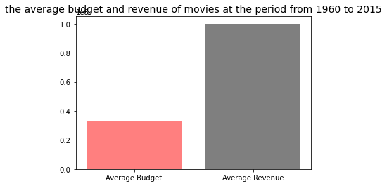

```python
# visualization to the two values
plt.bar(['Average Budget','Average Revenue'], [mean_budget, mean_revenue], color=['red', 'black'],alpha=0.5)
plt.title('the average budget and revenue of movies at the period from 1960 to 2015',fontsize=14)
plt.figure(figsize=(24, 24));
```

### Research Question 2 (What is the highest rating movie and who is it director in this period?)

```python
# we check for the  the highest rating movie
df[df.vote_average == df.vote_average.max()]
```

|  | popularity | budget | revenue | original_title | director | runtime | genres | vote_count | vote_average | release_year |
| --- | --- | --- | --- | --- | --- | --- | --- | --- | --- | --- |
| 3894 | 0.006925 | NaN | NaN | The Story of Film: An Odyssey | Mark Cousins | NaN | Documentary | 14 | 9.2 | 2011 |

The highest rating movie at that period is (The Story of Film: An Odyssey) and its director is (Mark Cousins)

### Research Question 3 (Does budget affect revenue over time?)

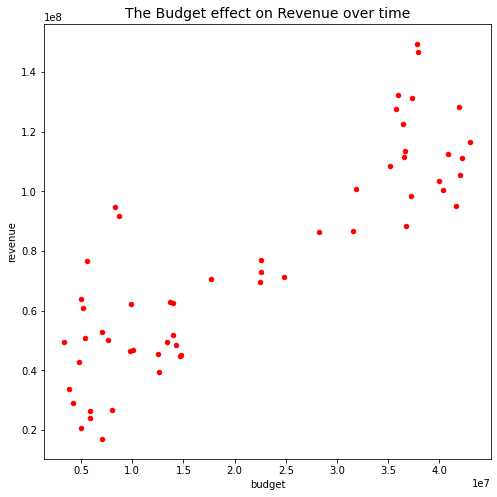

```python
# we droupby release_year and find the mean of budget and revenue and then plot the relation between them
budget_vs_revenue = df.groupby('release_year')[['budget','revenue']].mean()
budget_vs_revenue.plot(x='budget', y='revenue', kind='scatter',figsize=(8, 8),color='red')
plt.title('The Budget effect on Revenue over time', fontsize=14);
```

From the figure above we conclude that over time the more the budget the more the revenue.

### Research Question 4 (Do genres affect revenue?)

```python
# we check for the genre with highest revenue at this periode
df[df.revenue == df.revenue.max()]
```

|  | popularity | budget | revenue | original_title | director | runtime | genres | vote_count | vote_average | release_year |
| --- | --- | --- | --- | --- | --- | --- | --- | --- | --- | --- |
| 1386 | 9.432768 | 237000000.0 | 2.781506e+09 | Avatar | James Cameron | 162.0 | Action\|Adventure\|Fantasy\|Science Fiction | 8458 | 7.1 | 2009 |

```python
# we check for the genre with lowest revenue at this periode
df[df.revenue == df.revenue.min()]
```

|  | popularity | budget | revenue | original_title | director | runtime | genres | vote_count | vote_average | release_year |
| --- | --- | --- | --- | --- | --- | --- | --- | --- | --- | --- |
| 2097 | 0.554061 | 5000000.0 | 1000000.0 | Animal Kingdom | David MichÃ´d | 113.0 | Drama\|Thriller\|Crime | 117 | 6.7 | 2010 |
| 2191 | 0.332904 | NaN | 1000000.0 | Halo Legends | Shinji Aramaki\|Hideki Futamura | 93.0 | Action\|Animation\|Science Fiction | 19 | 7.2 | 2010 |
| 3818 | 0.331313 | NaN | 1000000.0 | Louis C.K.: Live at the Beacon Theater | Louis C.K. | 62.0 | Comedy | 47 | 7.9 | 2011 |
| 4831 | 0.139047 | NaN | 1000000.0 | Redd Inc. | Daniel Krige | 93.0 | Thriller\|Horror\|Comedy | 10 | 5.3 | 2012 |

The genre with highest revenue in this periode is (Action|Adventure|Fantasy|Science Fiction) The genres with lowest revenue in this periode are (Drama|Thriller|Crime),(Action|Animation|Science Fiction),(Comedy) and (Thriller|Horror|Comedy)

### Research Question 5 (Does runtime affect revenue over time?)

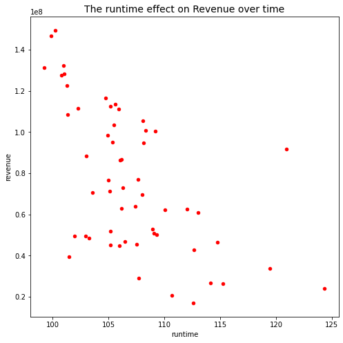

```python
# we droupby release_year and find the mean of runtime and revenue and then plot the relation between them
runtime_vs_revenue = df.groupby('release_year')[['runtime','revenue']].mean()
runtime_vs_revenue.plot(x='runtime', y='revenue', kind='scatter',figsize=(8, 8),color='red')
plt.title('The runtime effect on Revenue over time', fontsize=14);
```

in This periode, the movies with average runtime between 100 to 110 minute have average revenue more than other movies.

### Research Question 6 (Does vote affect revenue over time?)

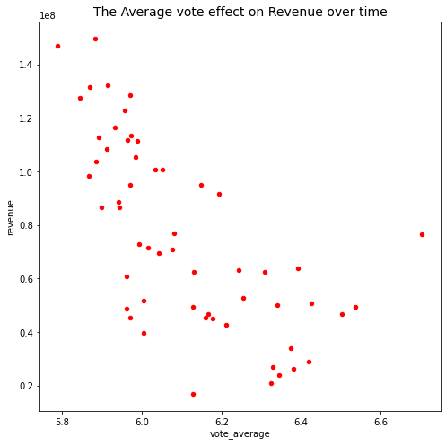

```python
# we droupby release_year and find the mean of runtime and vote_average and then plot the relation between them
vote_average_vs_revenue = df.groupby('release_year')[['vote_average','revenue']].mean()
vote_average_vs_revenue.plot(x='vote_average', y='revenue', kind='scatter',figsize=(8, 8),color='red')
plt.title('The Average vote effect on Revenue over time', fontsize=14);
```

# ----------------------------------------------------------------------------------------------------------------

## Conclusions

We investigated the TMDB movie dataset and we assessed,cleaned and explored it to answer our questions which are:

### 1)What is the average budget and revenue of movies at this period?

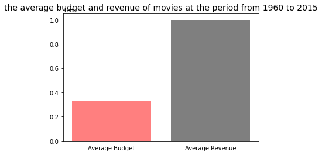

### 2)What is the highest rating movie and who is its director in this period?

=> The highest rating movie at that period is (The Story of Film: An Odyssey) and its director is (Mark Cousins)

### 3)Does budget affect revenue over time?

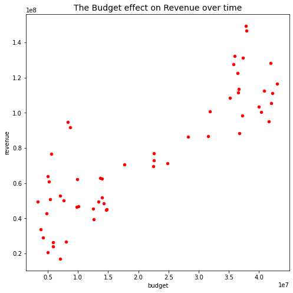

=> From the figure above we conclude that over time the more the budget the more the revenue.

### 5)Does runtime affect revenue over time?

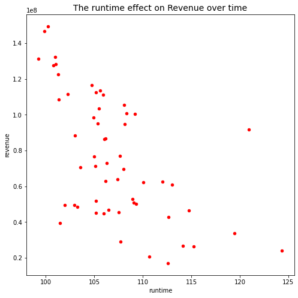

=> in This periode, the movies with average runtime between 100 to 110 minute have average revenue more than other movies.

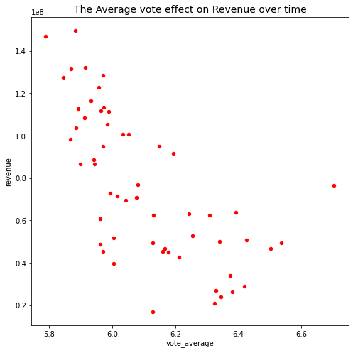